# CaseStudy2 Notebook

Jason Fields & Scott Payne

December 3, 2016

```r
knitr::opts_chunk$set(echo = TRUE)
```

# Documenting the code and package versions

```r
library(tseries)
```

## Question 1

Create the X matrix and print it from SAS, R, and Python.

SAS Matrix Input

proc IML;

X = {4 5 1 2, 1 0 3 5, 2 1 8 2};

print X;

R Matrix input

```r
 X <- matrix(c(4, 5, 1, 2, 1, 0, 3, 5, 2, 1, 8, 2),nrow = 3,ncol = 4,byrow = TRUE)
X
```

```
##      [,1] [,2] [,3] [,4]
## [1,]    4    5    1    2
## [2,]    1    0    3    5
## [3,]    2    1    8    2
```

Python Matrix input

```python
import numpy as np
X = np.matrix('4, 5, 1, 2; 1, 0, 3, 5; 2, 1, 8, 2')
print(X)
```

```
## [[4 5 1 2]
##  [1 0 3 5]
##  [2 1 8 2]]
```

## Question 2

Please do the following with your assigned stock. Jason & Scott: GW Pharamceuticals (GWPH)  
* Download the data. * Calculate log returns. * Calculate volatility measure. * Calculate volatility over entire length of series for various three different decay factors. * Plot the results, overlaying the volatility curves on the data, just as was done in the S&P example.

Download the data

```r
stock_data<-get.hist.quote('GWPH',quote="Close")
```

```
## time series starts 2013-05-01
```

```r
length(stock_data)
```

```
## [1] 911
```

Calculate log returns.

```r
stock_log<-log(lag(stock_data))-log(stock_data)
length(stock_log)
```

```
## [1] 910
```

Calculate volatility measure.

```r
stock_vol<-sd(stock_log)*sqrt(250)*100
print(stock_vol)
```

```
## [1] 74.18546
```

Calculate volatility over entire length of series for various three different decay factors.

```r
## volatility
Vol <- function(d, logrets)
{
    var = 0
    lam = 0
    varlist <- c()
    for (r in logrets) {
        lam = lam*(1 - 1/d) + 1
    var = (1 - 1/lam)*var + (1/lam)*r^2
        varlist <- c(varlist, var)
    }
    sqrt(varlist)
}
```

Plot the results, overlaying the volatility curves on the data, just as was done in the S&P example.

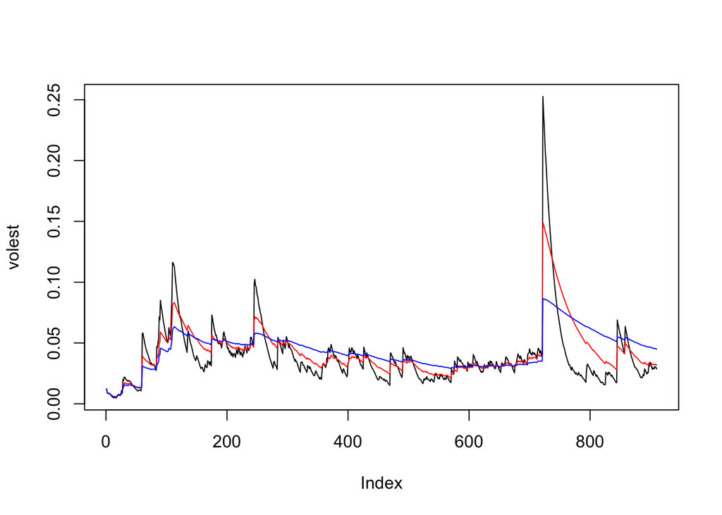

```r
# Recreate Figure 6.12 in the text on page 155

volest <- Vol(10,stock_log)
volest2 <- Vol(30,stock_log)
volest3 <- Vol(100,stock_log)
plot(volest,type="l")
lines(volest2,type="l",col="red")
lines(volest3, type = "l", col="blue")
```

## Question 3

The built-in data set called Orange in R is about the growth of orange trees. The Orange data frame has 3 columns of records of the growth of orange trees.

Variable description Tree : an ordered factor indicating the tree on which the measurement is made. The ordering is according to increasing maximum diameter. age : a numeric vector giving the age of the tree (days since 1968/12/31) circumference : a numeric vector of trunk circumferences (mm). This is probably “circumference at breast height”, a standard measurement in forestry.

load the data

```r
data("Orange")
Orange
```

```
##    Tree  age circumference
## 1     1  118            30
## 2     1  484            58
## 3     1  664            87
## 4     1 1004           115
## 5     1 1231           120
## 6     1 1372           142
## 7     1 1582           145
## 8     2  118            33
## 9     2  484            69
## 10    2  664           111
## 11    2 1004           156
## 12    2 1231           172
## 13    2 1372           203
## 14    2 1582           203
```

[output cut: 21 more lines]

1. Calculate the mean and the median of the trunk circumferences for different size of the trees. (Tree)

```r
tree_mean<-aggregate(Orange$circumference, list(Orange$Tree), FUN=mean)
tree_mean
```

```
##   Group.1         x
## 1       3  94.00000
## 2       1  99.57143
## 3       5 111.14286
## 4       2 135.28571
## 5       4 139.28571
```

```r
tree_median<-aggregate(Orange$circumference, list(Orange$Tree), FUN=median)
tree_median
```

```
##   Group.1   x
## 1       3 108
## 2       1 115
## 3       5 125
## 4       2 156
## 5       4 167
```

2. Make a scatter plot of the trunk circumferences against the age of the tree. Use different plotting symbols for different size of trees.

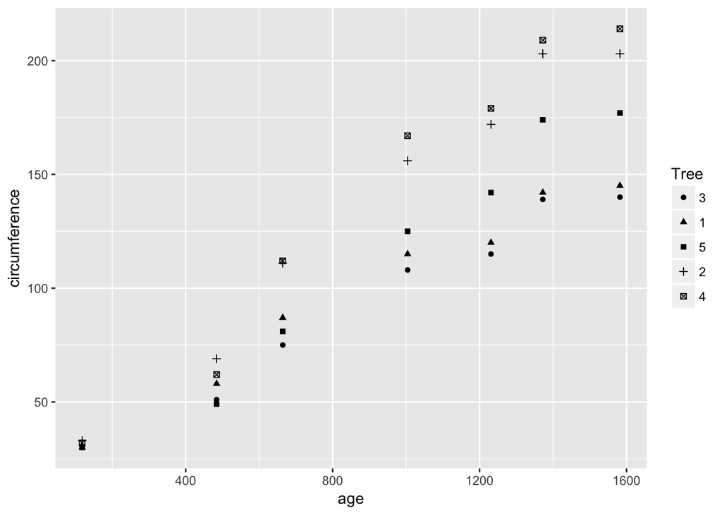

```r
library(ggplot2)
ggplot(Orange, aes(y=circumference, x=age, shape=Tree)) +
    geom_point()
```

3. Display the trunk circumferences on a comparative boxplot against tree. Be sure you order the boxplots in the increasing order of maximum diameter.

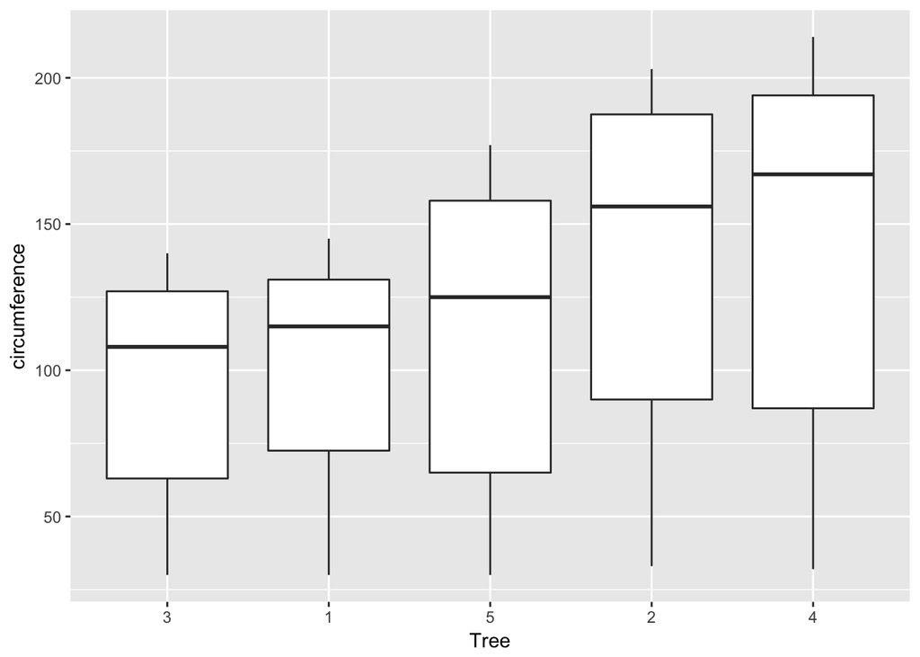

```r
ggplot(Orange, aes(y=circumference, x=Tree)) +
    geom_boxplot()
```

## Question 4

Download “Temp” data set (check your SMU email)

```r
temp<-read.csv('Temp.csv', header = TRUE,
         dec = ".", fill = TRUE )
head(temp)
```

```
##         Date Monthly.AverageTemp Monthly.AverageTemp.Uncertainty
## 1 1838-04-01              13.008                           2.586
## 2 1838-05-01                  NA                              NA
## 3 1838-06-01              23.950                           2.510
## 4 1838-07-01              26.877                           2.883
## 5 1838-08-01              24.938                           2.992
## 6 1838-09-01              18.981                           2.538
##       Country
## 1 Afghanistan
## 2 Afghanistan
## 3 Afghanistan
## 4 Afghanistan
## 5 Afghanistan
## 6 Afghanistan
```

```r
summary(temp)
```

```
##        Date        Monthly.AverageTemp Monthly.AverageTemp.Uncertainty
##  1/1/1951:   242   Min.   :-37.66      Min.   : 0.05
##  1/1/1952:   242   1st Qu.: 10.16      1st Qu.: 0.32
##  1/1/1953:   242   Median : 21.00      Median : 0.57
##  1/1/1954:   242   Mean   : 17.26      Mean   : 1.01
##  1/1/1955:   242   3rd Qu.: 25.83      3rd Qu.: 1.20
##  1/1/1956:   242   Max.   : 38.84      Max.   :15.00
##  (Other) :572771   NA's   :32578       NA's   :31839
##                    Country
##  Albania               :  3239
##  Andorra               :  3239
##  Austria               :  3239
##  Belarus               :  3239
##  Belgium               :  3239
##  Bosnia And Herzegovina:  3239
##  (Other)               :554789
```

1. Find the difference between the maximum and the minimum monthly average temperatures for each country and report/visualize top 20 countries with the maximum differences for the period since 1900.

```r
temp$Country <- as.character(temp$Country)

library(lubridate)
#package to parse multiple date formats
temp$Date <- parse_date_time(x = temp$Date,
                             orders = c("y-m-d", "m/d/y"),
                             locale = "eng")
#select dates 1900 and later
temp <- temp[temp$Date > "1899-12-1",]

# Max Average Monthly Temperature by Country
max.temp <-aggregate(temp$Monthly.AverageTemp, list(temp$Country), FUN=max, na.rm = T)
# Min Average Monthly Temperature by Country
min.temp <- aggregate(temp$Monthly.AverageTemp, list(temp$Country), FUN=min, na.rm = T)
# Difference in Min and Max
diff.temp <- (max.temp[2] - min.temp[2])

# Add Countries to temp.diff
diff.temp$Country <- max.temp$Group.1

# Sort by largest difference
diff.temp <- diff.temp[order(-diff.temp$x),]

high.temp.variation <- diff.temp[1:20,1:2]
# high.temp.variation$Country <- as.character(high.temp.variation$Country)
names(high.temp.variation) <- c("Temp", "Country")
#class(high.temp.variation$Country)
```

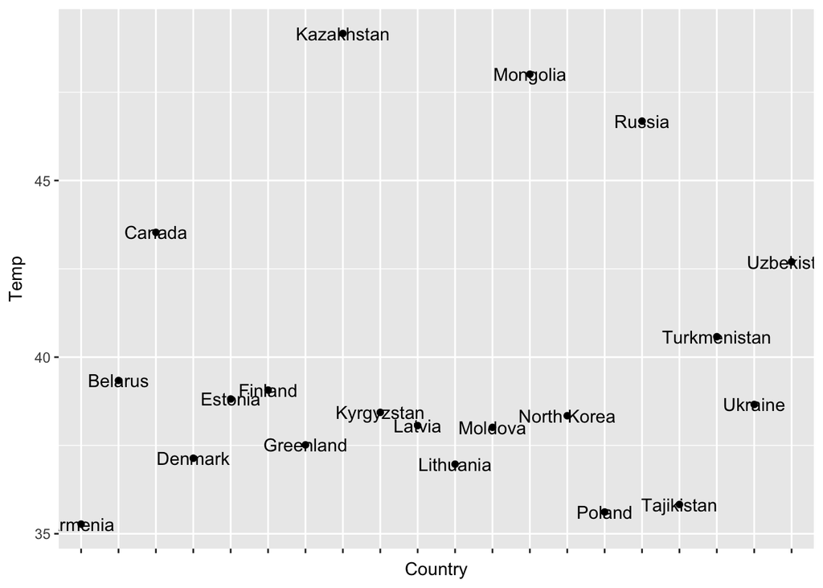

```r
plot_q4_i<-ggplot(high.temp.variation, aes(Country,Temp, labels(high.temp.variation$Country))) + geom_point(stat="identity")+ xlab("Country") + theme(axis.text.x=element_blank()) + geom_text(aes(label=high.temp.variation$Country))
plot_q4_i
```

```r
UStemp <- temp[temp$Country == 'United States',]
head(temp)
```

```
##           Date Monthly.AverageTemp Monthly.AverageTemp.Uncertainty
## 742 1900-01-01              -3.428                           0.936
## 743 1900-02-01               1.234                           1.135
## 744 1900-03-01              10.545                           0.933
## 745 1900-04-01              13.352                           0.536
## 746 1900-05-01              20.260                           0.524
## 747 1900-06-01              24.448                           0.944
##         Country
## 742 Afghanistan
## 743 Afghanistan
## 744 Afghanistan
## 745 Afghanistan
## 746 Afghanistan
## 747 Afghanistan
```

```r
summary(temp)
```

```
##       Date                     Monthly.AverageTemp
##  Min.   :1900-01-01 00:00:00   Min.   :-37.18
##  1st Qu.:1928-08-01 00:00:00   1st Qu.: 13.32
##  Median :1957-03-01 00:00:00   Median : 23.26
##  Mean   :1957-01-06 21:20:44   Mean   : 18.89
##  3rd Qu.:1985-06-01 00:00:00   3rd Qu.: 26.36
##  Max.   :2013-09-01 00:00:00   Max.   : 38.84
##                                NA's   :1049
##  Monthly.AverageTemp.Uncertainty   Country
##  Min.   :0.0520                  Length:328503
##  1st Qu.:0.2590                  Class :character
##  Median :0.3650                  Mode  :character
##  Mean   :0.4476
##  3rd Qu.:0.5390
##  Max.   :8.4250
##  NA's   :310
```

1. Create a new column to display the monthly average land temperatures in Fahrenheit (°F).

```r
library(weathermetrics)
UStemp$Monthly.AverageTempF <- convert_temperature(UStemp$Monthly.AverageTemp, old_metric = "celsius", new_metric = "fahrenheit")
```

2. Calculate average land temperature by year and plot it. The original file has the average land temperature by month.

```r
UStemp$Year <- format(UStemp$Date,format="%Y")
Yearly <- aggregate(UStemp$Monthly.AverageTempF ~ Year , UStemp, mean, na.rm = T)
```

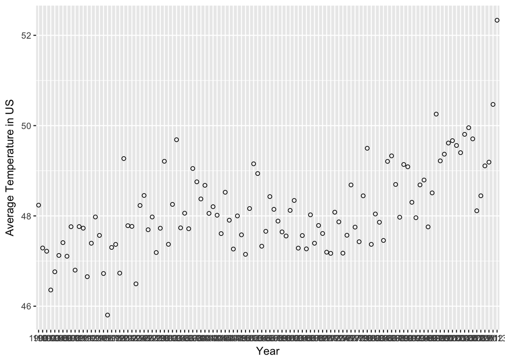

```r
ggplot(Yearly, aes(x=Year, y=`UStemp$Monthly.AverageTempF`)) +
geom_point(shape=1) + xlab("Year") + ylab("Average Temperature in US")
```

3. Calculate the one year difference of average land temperature by year and provide the maximum difference (value) with corresponding two years. (for example, year 2000: add all 12 monthly averages and divide by 12 to get average temperature in 2000. You can do the same thing for all the available years. Then you can calculate the one year difference as 1991-1990, 1992-1991, etc)

```r
Yearly$two.year <- diff(c(0,Yearly$`UStemp$Monthly.AverageTempF`))
Yearly$two.year
```

```
##   [1] 48.23833333 -0.94916667 -0.07083333 -0.85916667  0.40333333
##   [6]  0.36250000  0.28333333 -0.30166667  0.65416667 -0.96166667
##  [11]  0.96416667 -0.03500000 -1.07416667  0.74083333  0.58166667
##  [16] -0.40833333 -0.84416667 -0.92000000  1.49750000  0.06750000
##  [21] -0.63666667  2.53833333 -1.48750000 -0.01500000 -1.27333333
##  [26]  1.73583333  0.22166667 -0.75833333  0.28250000 -0.78750000
##  [31]  0.53833333  1.48250000 -1.83916667  0.88416667  1.43250000
##  [36] -1.95166667  0.32416667 -0.34416667  1.33416667 -0.29500000
##  [41] -0.37916667  0.30166667 -0.62166667  0.14833333 -0.18833333
##  [46] -0.40750000  0.91583333 -0.61916667 -0.63833333  0.73333333
##  [51] -0.41916667 -0.43166667  1.01416667  0.99083333 -0.21583333
##  [56] -1.60916667  0.33000000  0.76833333 -0.28166667 -0.26000000
##  [61] -0.24000000 -0.09083333  0.56750000  0.22000000 -1.05583333
##  [66]  0.27833333 -0.29500000  0.75416667 -0.62916667  0.39333333
##  [71] -0.17750000 -0.41416667 -0.02583333  0.91166667 -0.21416667
##  [76] -0.69333333  0.39666667  1.11416667 -0.93416667 -0.32333333
##  [81]  1.01666667  1.05333333 -2.12833333  0.67250000 -0.18250000
##  [86] -0.40333333  1.75083333  0.12250000 -0.63333333 -0.72583333
##  [91]  1.16833333 -0.05083333 -0.78666667 -0.34166667  0.72666667
##  [96]  0.10833333 -1.03833333  0.75333333  1.74500000 -1.03583333
## [101]  0.14833333  0.24666667  0.05333333 -0.10750000 -0.15916667
## [106]  0.40583333  0.14750000 -0.24750000 -1.59333333  0.33250000
## [111]  0.66250000  0.08250000  1.27833333  1.86527778
```

3. Download “CityTemp” data set (check your SMU email). Find the difference between the maximum and the minimum temperatures for each major city and report/visualize top 20 cities with maximum differences for the period since 1900.

Read in the the CityTemp file.

```r
CityTemp<-read.csv('CityTemp.csv', header = TRUE,
         dec = ".", fill = TRUE )
```

Summarize the data

```r
head(CityTemp)
```

```
##         Date Monthly.AverageTemp Monthly.AverageTemp.Uncertainty
## 1 1850-01-01              15.986                           1.537
## 2 1850-02-01              18.345                           1.527
## 3 1850-03-01              18.632                           2.162
## 4 1850-04-01              18.154                           1.693
## 5 1850-05-01              17.480                           1.237
## 6 1850-06-01              17.183                           1.252
##          City  Country Latitude Longitude
## 1 Addis Abeba Ethiopia    8.84N    38.11E
## 2 Addis Abeba Ethiopia    8.84N    38.11E
## 3 Addis Abeba Ethiopia    8.84N    38.11E
## 4 Addis Abeba Ethiopia    8.84N    38.11E
## 5 Addis Abeba Ethiopia    8.84N    38.11E
## 6 Addis Abeba Ethiopia    8.84N    38.11E
```

```r
summary(CityTemp)
```

```
##        Date        Monthly.AverageTemp Monthly.AverageTemp.Uncertainty
##  1/1/1900:    99   Min.   :-26.77      Min.   : 0.040
##  1/1/1901:    99   1st Qu.: 12.62      1st Qu.: 0.340
##  1/1/1902:    99   Median : 20.33      Median : 0.593
##  1/1/1903:    99   Mean   : 18.06      Mean   : 0.972
##  1/1/1904:    99   3rd Qu.: 25.88      3rd Qu.: 1.324
##  1/1/1905:    99   Max.   : 38.28      Max.   :14.037
##  (Other) :236606   NA's   :10802       NA's   :10802
##        City                 Country          Latitude
##  Berlin  :  3239   India        : 36582   31.35N : 13875
##  Chicago :  3239   China        : 35444   40.99N : 11930
##  Istanbul:  3239   Brazil       : 12930   39.38N :  9954
##  Kiev    :  3239   Turkey       :  9473   23.31N :  9924
##  London  :  3239   United States:  8455   37.78N :  9862
##  Madrid  :  3239   Egypt        :  7589   29.74N :  9078
##  (Other) :217766   (Other)      :126727   (Other):172577
##    Longitude
##  31.38E :  6801
##  77.27E :  5226
##  80.60E :  5226
##  73.51E :  4742
##  116.53E:  4636
##  103.66E:  4583
##  (Other):205986
```

```r
str(CityTemp)
```

```
## 'data.frame':    237200 obs. of  7 variables:
##  $ Date                           : Factor w/ 3239 levels "1/1/1900","1/1/1901",..: 1728 1729 1730 1731 1732 1733 1734 1735 1736 1737 ...
##  $ Monthly.AverageTemp            : num  16 18.3 18.6 18.2 17.5 ...
##  $ Monthly.AverageTemp.Uncertainty: num  1.54 1.53 2.16 1.69 1.24 ...
##  $ City                           : Factor w/ 99 levels "Addis Abeba",..: 1 1 1 1 1 1 1 1 1 1 ...
##  $ Country                        : Factor w/ 48 levels "Afghanistan",..: 14 14 14 14 14 14 14 14 14 14 ...
##  $ Latitude                       : Factor w/ 49 levels "0.80N","0.80S",..: 48 48 48 48 48 48 48 48 48 48 ...
##  $ Longitude                      : Factor w/ 92 levels "0.00W","103.66E",..: 48 48 48 48 48 48 48 48 48 48 ...
```

Align date formats and subset for after the year 1900

```r
library(lubridate)
#package to parse multiple date formats and aligbn to single format
CityTemp$Date <- parse_date_time(x = CityTemp$Date,
                            orders = c("y-m-d", "m/d/y")
                            )
#select dates 1900 and later
CityTemp <- CityTemp[CityTemp$Date > "1899-12-1",]
```

Reshape the data to do analysis

```r
library(dplyr, tidyr)
#drop unneeded columns
CityTemp<-select(CityTemp, -Latitude, -Longitude  )
```

```r
# Max Average Monthly Temperature by City
max.CityTemp <-aggregate(CityTemp$Monthly.AverageTemp, list(CityTemp$City), FUN=max, na.rm = T)

# Min Average Monthly Temperature by Country
min.CityTemp <- aggregate(CityTemp$Monthly.AverageTemp, list(CityTemp$City), FUN=min, na.rm = T)

# Difference in Min and Max
diff.CityTemp <- (max.CityTemp[2] - min.CityTemp[2])

# Add Cities to CityTemp.diff
diff.CityTemp$City <- max.CityTemp$Group.1

# Sort by largest difference
diff.CityTemp <- diff.CityTemp[order(-diff.CityTemp$x),]
high.CityTemp.variation <- diff.CityTemp[1:20,1:2]
high.CityTemp.variation$City<-as.character(high.CityTemp.variation$City)
```

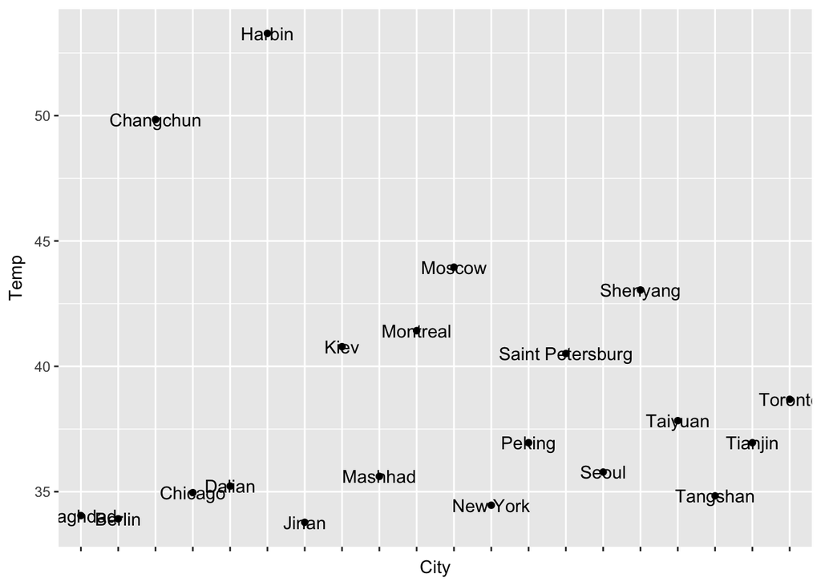

```r
plot_q4_iii<-ggplot(high.CityTemp.variation, aes(City,x, labels(high.CityTemp.variation.variation$City))) + geom_point(stat="identity")+ xlab("City") + ylab("Temp") +  theme(axis.text.x=element_blank()) + geom_text(aes(label=high.CityTemp.variation$City))
plot_q4_iii
```

(iv) Compare the two graphs in (i) and (iii) and comment it.

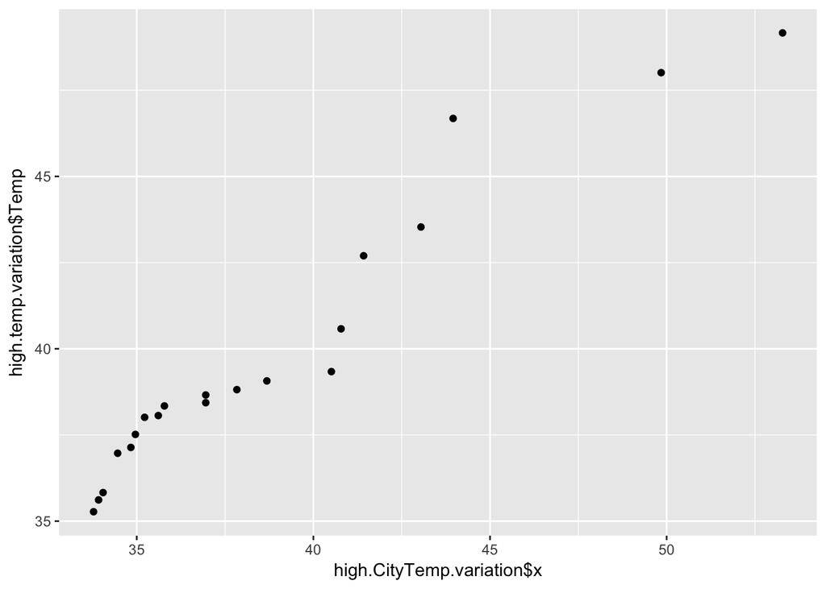

```r
dat<-data.frame(high.temp.variation,high.CityTemp.variation)

ggplot(dat,aes(y=high.temp.variation$Temp,x=high.CityTemp.variation$x))+geom_point()
```

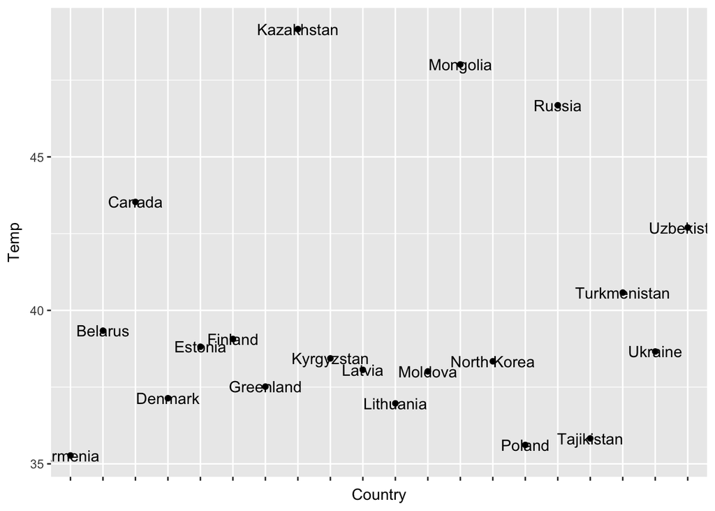

```r
#Compare the two plots
plot_q4_i
```

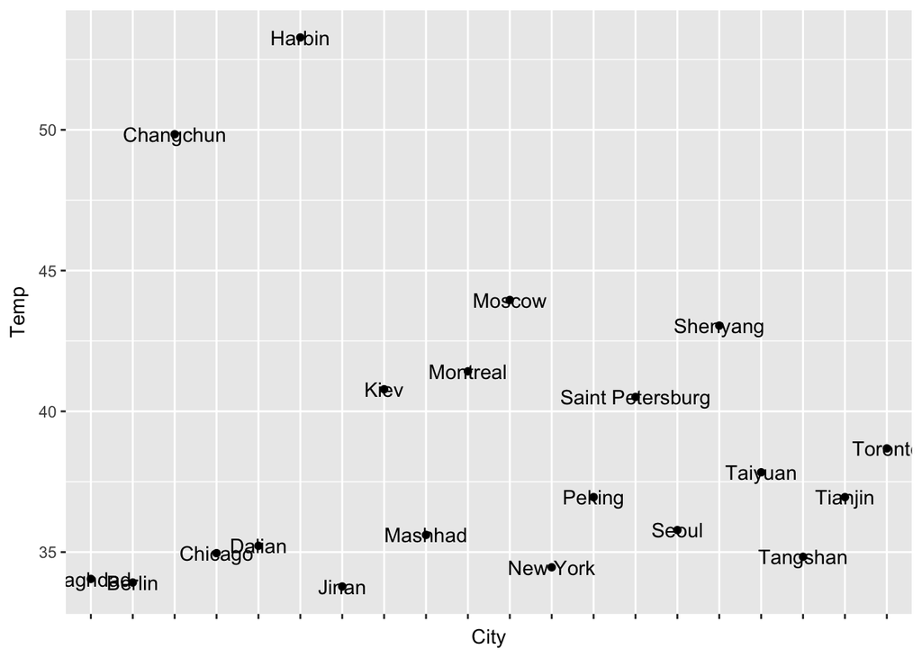

```r
plot_q4_iii
```

The two charts show very similar trends between cities and countries.